# Pokemon Stat EDA

Marcellito Vido T

6/10/2020

# Deskripsi Data

Data set ini berisi 721 Pokemon, termasuk nomor, nama, tipe 1 dan 2, dan statistik dasar: HP, Attack, Defense, Special Attack, Special Defense, dan Speed. Data ini adalh data mentah yang akan digunakan iuntuk menghitung berapa banyak damage sebuah serangan dalam games. Dataset ini adalah tentang game *Pokemon* (Bukan *pokemon cards* atau *Pokemon Go*).

> Deskripsi Kolom
- **Name**: Nama setiap pokemon
- **Type 1**: Setiap pokemon memiliki tipe, ini menentukan kelemahan/kekuatan pokemon
- **Type 2**: Beberapa pokemon memiliki 2 tipe
- **Total**: Jumlah dari semua statistik pokemon, dalam kasus ini bisa disebut juga Power
- **HP**: hit points, atau nyawa, menentukan berapa banyak damage yang bisa ditahan sebelum pingsan
- **Attack**: damage serangan normal (Cth: Scratch, Punch)
- **Defense**: Damage rasistance terhadap serangan normal
- **SP Atk**: special attack, Damage special attack (Cth: fire blast, bubble beam)
- **SP Def**: Damage rasistance terhadap special attacks
- **Speed**: Menentukan pokemon mana yang akan menyerang lebih dulu di setiap round
- **Generation**: Pokemon dapat berevolusi, ini menentukan evolusi keberapa
- **Legendary**: Beberapa pokemon termasuk dalam pokemon legendary

> Sumber Data

Data ini saya dapatkan di situs: https://www.kaggle.com/abcsds/pokemon

> Permasalahan

Beberapa pertanyaan yang dapat dijawab dengan dataset ini:

1. Pokemon tipe apa yang memiliki jenis paling banyak dan paling sedikit?
2. Pokemon generasi berapa yang memiliki jenis paling banyak dan paling sedikit?
3. Berapa HP yang dimiliki setiap pokemon?  
   Etc..

> Ringkasan Data

```
## Rows: 800
## Columns: 13
## $ X.         <int> 1, 2, 3, 3, 4, 5, 6, 6, 6, 7, 8, 9, 9, 10, 11, 12, 13, 1...
## $ Name       <chr> "Bulbasaur", "Ivysaur", "Venusaur", "VenusaurMega Venusa...
## $ Type.1     <chr> "Grass", "Grass", "Grass", "Grass", "Fire", "Fire", "Fir...
## $ Type.2     <chr> "Poison", "Poison", "Poison", "Poison", "", "", "Flying"...
## $ Total      <int> 318, 405, 525, 625, 309, 405, 534, 634, 634, 314, 405, 5...
## $ HP         <int> 45, 60, 80, 80, 39, 58, 78, 78, 78, 44, 59, 79, 79, 45, ...
## $ Attack     <int> 49, 62, 82, 100, 52, 64, 84, 130, 104, 48, 63, 83, 103, ...
## $ Defense    <int> 49, 63, 83, 123, 43, 58, 78, 111, 78, 65, 80, 100, 120, ...
## $ Sp..Atk    <int> 65, 80, 100, 122, 60, 80, 109, 130, 159, 50, 65, 85, 135...
## $ Sp..Def    <int> 65, 80, 100, 120, 50, 65, 85, 85, 115, 64, 80, 105, 115,...
## $ Speed      <int> 45, 60, 80, 80, 65, 80, 100, 100, 100, 43, 58, 78, 78, 4...
## $ Generation <int> 1, 1, 1, 1, 1, 1, 1, 1, 1, 1, 1, 1, 1, 1, 1, 1, 1, 1, 1,...
## $ Legendary  <chr> "False", "False", "False", "False", "False", "False", "F...
```

# Pre-Processing Data

Library yang akan digunakan

```r
library(tidyverse)  # Import/Export Dataframe
library(dplyr)      # Pre-Processing Data
library(ggplot2)    # Data Visualization
```

> Import Dataset

Import dataset yang akan dianalisis kedalam bentuk dataframe menggunakan fungsi *read.csv()*

```r
pokemon = read.csv('dataset/Pokemon/datasets_121_280_Pokemon.csv')
glimpse(pokemon)
```

```
## Rows: 800
## Columns: 13
## $ X.         <int> 1, 2, 3, 3, 4, 5, 6, 6, 6, 7, 8, 9, 9, 10, 11, 12, 13, 1...
## $ Name       <chr> "Bulbasaur", "Ivysaur", "Venusaur", "VenusaurMega Venusa...
## $ Type.1     <chr> "Grass", "Grass", "Grass", "Grass", "Fire", "Fire", "Fir...
## $ Type.2     <chr> "Poison", "Poison", "Poison", "Poison", "", "", "Flying"...
## $ Total      <int> 318, 405, 525, 625, 309, 405, 534, 634, 634, 314, 405, 5...
## $ HP         <int> 45, 60, 80, 80, 39, 58, 78, 78, 78, 44, 59, 79, 79, 45, ...
## $ Attack     <int> 49, 62, 82, 100, 52, 64, 84, 130, 104, 48, 63, 83, 103, ...
## $ Defense    <int> 49, 63, 83, 123, 43, 58, 78, 111, 78, 65, 80, 100, 120, ...
## $ Sp..Atk    <int> 65, 80, 100, 122, 60, 80, 109, 130, 159, 50, 65, 85, 135...
## $ Sp..Def    <int> 65, 80, 100, 120, 50, 65, 85, 85, 115, 64, 80, 105, 115,...
## $ Speed      <int> 45, 60, 80, 80, 65, 80, 100, 100, 100, 43, 58, 78, 78, 4...
## $ Generation <int> 1, 1, 1, 1, 1, 1, 1, 1, 1, 1, 1, 1, 1, 1, 1, 1, 1, 1, 1,...
## $ Legendary  <chr> "False", "False", "False", "False", "False", "False", "F...
```

> Data Preparation

Agar lebih mudah dipahami saya mengubah header kolom *Total* –> *Power*  
dengan fungsi *rename()*

```r
pokemon = pokemon %>%
  rename(Power = Total)
```

Mengubah tipedata pada beberapa kolom menggunakan fungsi *as.factor()*

```r
pokemon$Type.1 = as.factor(pokemon$Type.1)
pokemon$Type.2 = as.factor(pokemon$Type.2)
pokemon$Generation = as.factor(pokemon$Generation)
pokemon$Legendary = as.factor(pokemon$Legendary)

pokemon %>%
  select(Type.1, Type.2, Generation, Legendary)%>%
  glimpse()
```

```
## Rows: 800
## Columns: 4
## $ Type.1     <fct> Grass, Grass, Grass, Grass, Fire, Fire, Fire, Fire, Fire...
## $ Type.2     <fct> Poison, Poison, Poison, Poison, , , Flying, Dragon, Flyi...
## $ Generation <fct> 1, 1, 1, 1, 1, 1, 1, 1, 1, 1, 1, 1, 1, 1, 1, 1, 1, 1, 1,...
## $ Legendary  <fct> False, False, False, False, False, False, False, False, ...
```

# Exploratory Data Analysis

> VARIATION: Categorical Variable  
> **Pokemon tipe apa yang memiliki jenis paling banyak dan paling sedikit?**

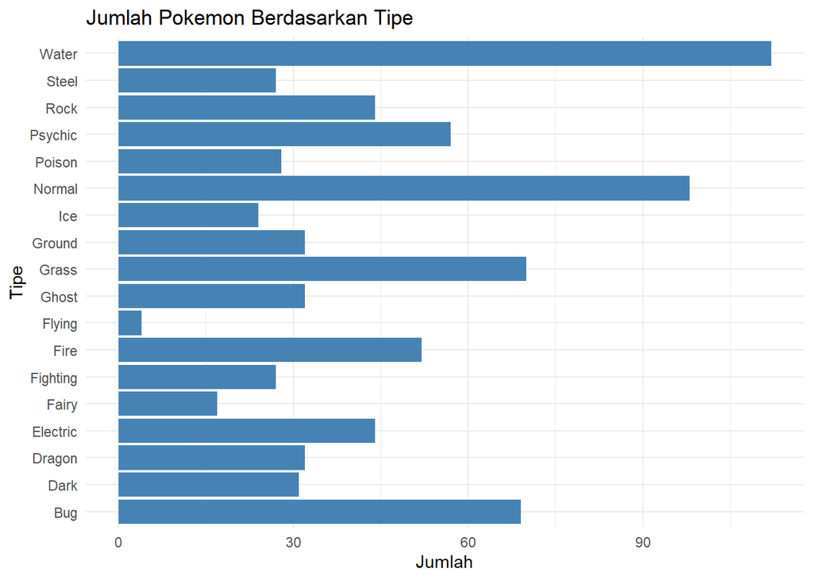

```r
TypePlot = ggplot(pokemon)+
  geom_bar(mapping = aes(Type.1), fill="steelblue")+
  ggtitle("Jumlah Pokemon Berdasarkan Tipe")+
  xlab('Tipe')+ylab('Jumlah')+
  coord_flip()+
  theme_minimal()
```

Untuk mengetahui frekuensi secara detail saya menggunakan fungsi *count()* dari library *plyr*

```r
TypeCount = plyr::count(pokemon, 'Type.1')
```

Interpretasi :

1. Pokemon dengan tipe Air (Water) memiliki jenis paling banyak yaitu **112**
2. Pokemon dengan tipe tebang (Flying) memuliki jenis paling sedikit yaitu **4**  
   Etc..

> VARIATION: Categorical Variable  
> **Pokemon generasi berapa yang memiliki jenis paling banyak dan paling sedikit?**

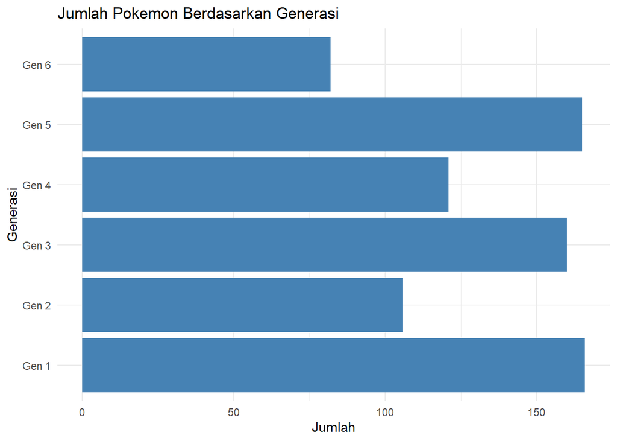

```r
GenPlot = ggplot(pokemon)+
  geom_bar(mapping = aes(Generation), fill="steelblue")+
  ggtitle("Jumlah Pokemon Berdasarkan Generasi")+
  xlab('Generasi')+ylab('Jumlah')+
  scale_x_discrete(breaks=c('1', '2', '3', '4', '5', '6'),
                   labels = c('Gen 1', 'Gen 2', 'Gen 3', 'Gen 4', 'Gen 5', 'Gen 6'))+
  coord_flip()+
  theme_minimal()
```

Untuk mengetahui frekuensi secara detail saya menggunakan fungsi *count()* dari library *plyr*

```r
GenCount = plyr::count(pokemon, 'Generation')
```

Interpretasi :

1. Pokemon dengan generasi 1 memiliki jenis yang paling banyak yaitu **166**
2. Pokemon dengan generasi 6 memiliki jenis yang paling Sedikit yaitu **82**  
   Etc..

> VARIATION: Continous Variable  
> **Bagaimana sebaran HP yang dimiliki pokemon?**

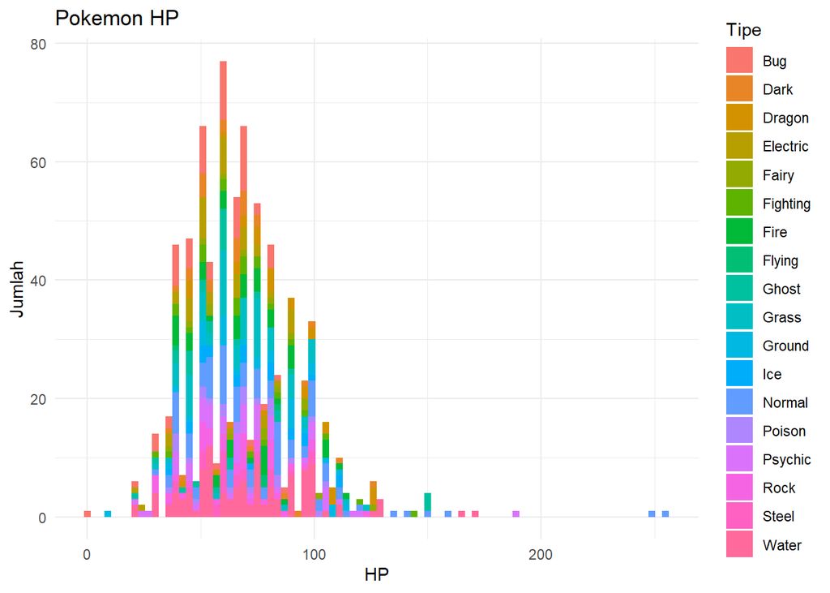

```r
HpPlot = ggplot(pokemon)+
  geom_histogram(mapping = aes(x=HP, fill = Type.1), binwidth = 3)+
  xlab('HP')+ylab('Jumlah')+
  ggtitle("Pokemon HP")+ labs(fill = "Tipe")+
  theme_minimal()
```

> VARIATION: Continous Variable  
> **Bagaimana sebaran Attack yang dimiliki pokemon?**

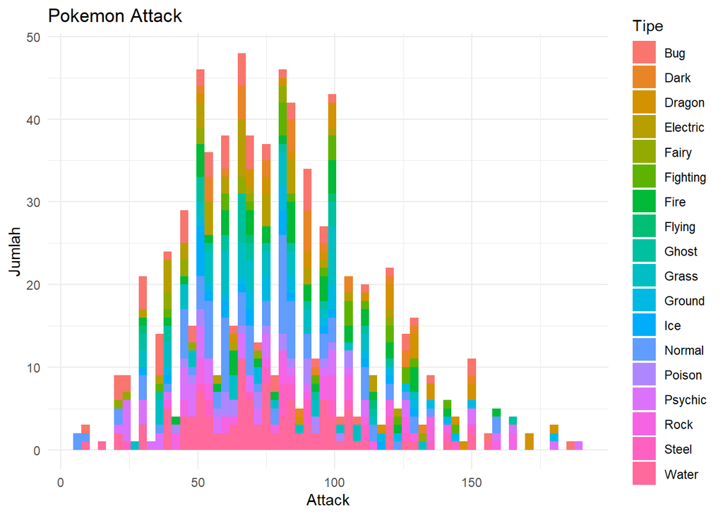

```r
AttPlot = ggplot(pokemon)+
  geom_histogram(mapping = aes(x=Attack, fill = Type.1), binwidth = 3)+
  xlab('Attack')+ylab('Jumlah')+
  ggtitle("Pokemon Attack")+ labs(fill = "Tipe")+
  theme_minimal()
```

Interpretasi :

— Mayoritas pokemon memiliki Attack dibawah 150  
Etc..

> COVARIATION: Categorical vs Categorical  
> **Pokemon Legendary paling banyak pada tipe apa?**

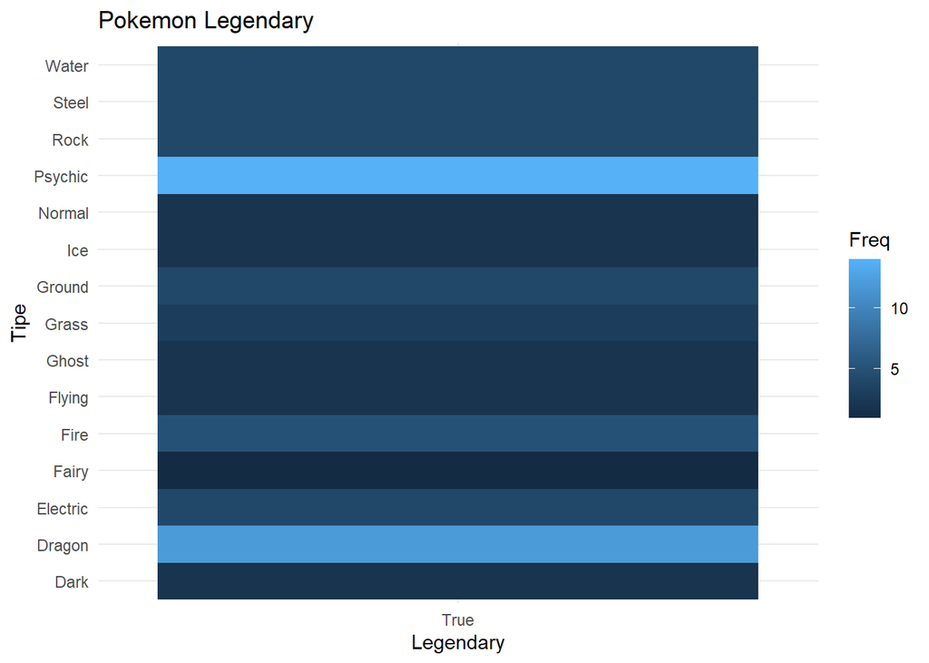

```r
LegendPlot = pokemon %>%
  filter(Legendary == "True")%>%
  count(Type.1, Legendary) %>%
  arrange(desc(n))%>%
  ggplot(mapping = aes(x=Legendary, y=Type.1))+
  geom_tile(mapping = aes(fill = n))+
  ggtitle("Pokemon Legendary")+ labs(fill = "Freq")+
  ylab('Tipe')+
  theme_minimal()
```

Untuk mengetahui data secara detail

```r
LegendCount = pokemon %>%
  filter(Legendary == "True")%>%
  count(Type.1, Legendary) %>%
  arrange(desc(n))
```

> COVARIATION: Categorical vs Categorical  
> **Pokemon generasi 1-6 banyak bertipe apa?**

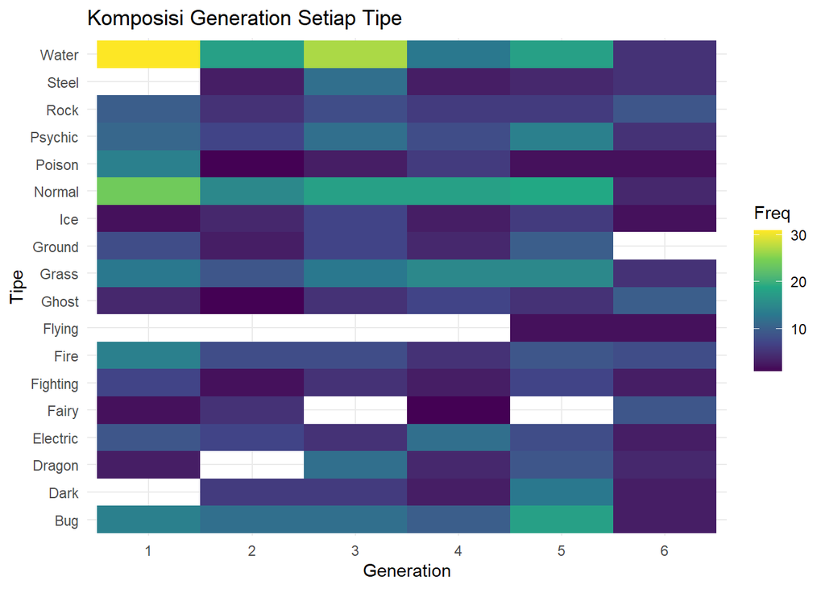

```r
GenComPlot = pokemon %>%
  count(Type.1, Generation) %>%
  arrange(desc(n))%>%
  ggplot(mapping = aes(x=Generation, y=Type.1))+
  geom_tile(mapping = aes(fill = n))+
  ggtitle("Komposisi Generation Setiap Tipe")+ labs(fill = "Freq")+
  ylab('Tipe')+
  scale_fill_viridis_c()+
  theme_minimal()
```

Untuk mengetahui data secara detail

```r
GenComposition = pokemon %>%
  count(Type.1, Generation) %>%
  arrange(Type.1)
```

Interpretasi :

1. Pokemon generasi 1 banyak bertipe Water
2. Pokemon generasi 2 banyak bertipe Water dan Normal
3. Pokemon generasi 3 banyak bertipe Water
4. Pokemon generasi 4 banyak bertipe Normal
5. Pokemon generasi 5 banyak bertipe Normal dan Bug
6. Pokemon generasi 6 banyak bertipe Ghost  
   Etc..

> COVARIATION: Continous vs Continous  
> **Apakah semakin tinggi Attack, semakin tinggi juga Special Attack?**

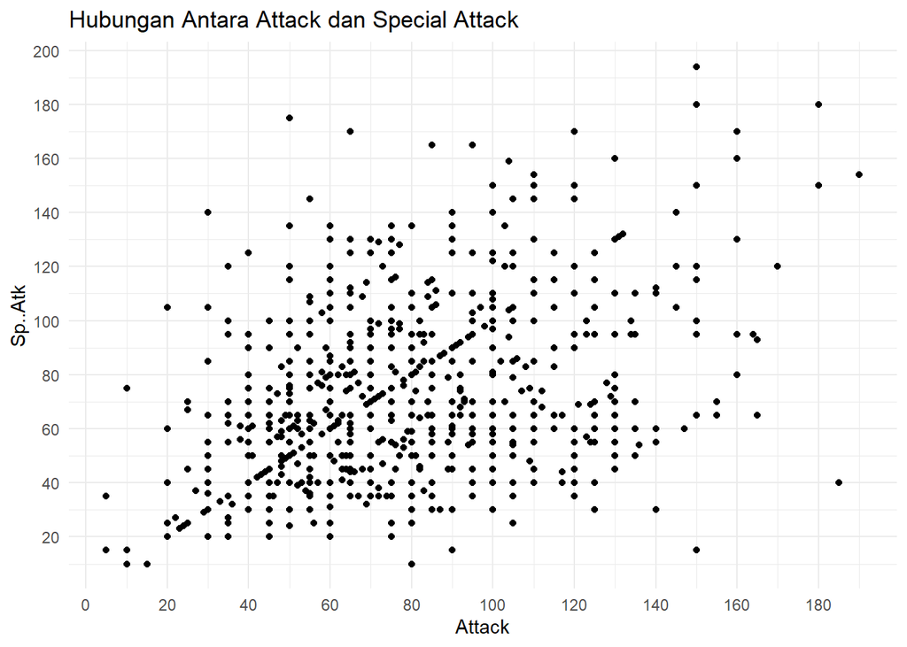

```r
AttRelPlot = ggplot(pokemon, aes(Attack, Sp..Atk))+
  geom_point() +
  scale_x_continuous(breaks = seq(0,200,20))+
  scale_y_continuous(breaks = seq(0,200,20))+
  ggtitle('Hubungan Antara Attack dan Special Attack')+
  theme_minimal()
```

Menghitung korelasi antara variabel Attack dan Sp..Atk, saya menggunakan method *Pearson*

```r
r_att = cor.test(pokemon$Attack, pokemon$Sp..Atk,
             method = "pearson")
```

Interpretasi :

— Variabel Attack dan Sp..Atk memiliki relasi positif sedang (Moderate Positive Relationship) **+0.3963618**  
Etc..

> COVARIATION: Continous vs Continous  
> **Apakah semakin tinggi Defense, semakin tinggi juga Special Deffense?**

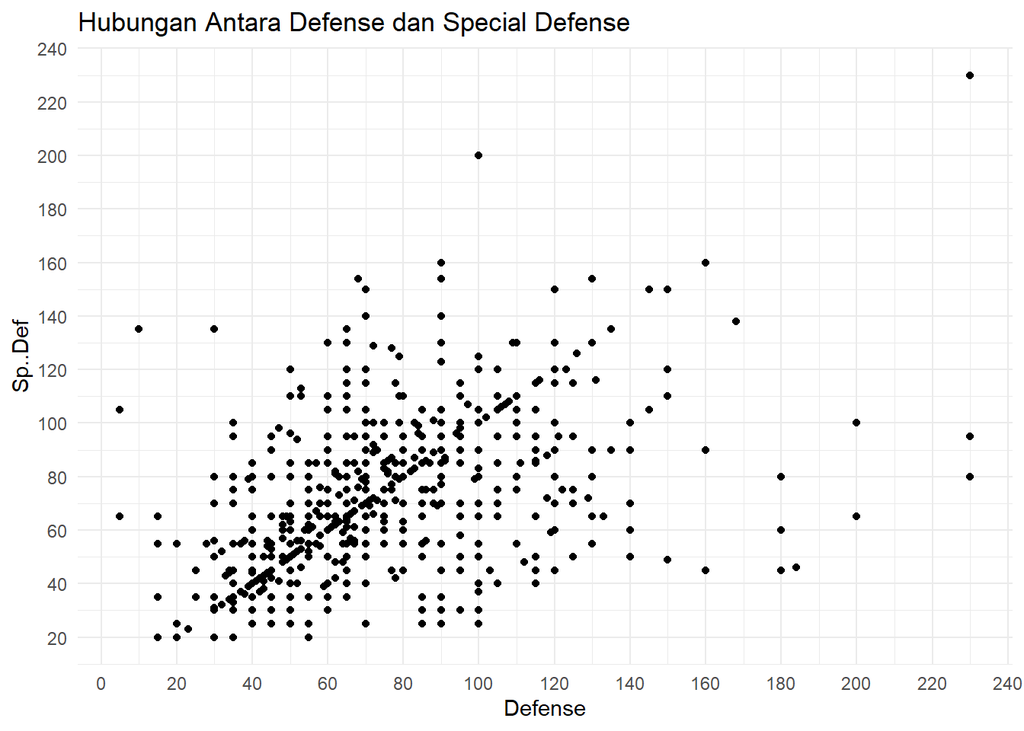

```r
DefRelPlot = ggplot(pokemon, aes(Defense, Sp..Def))+
  geom_point() +
  ggtitle('Hubungan Antara Defense dan Special Defense')+
  scale_x_continuous(breaks = seq(0,240,20))+
  scale_y_continuous(breaks = seq(0,240,20))+
  theme_minimal()
```

```r
r_def = cor.test(pokemon$Defense, pokemon$Sp..Def,
         method = "pearson")
```

Interpretasi :

— Variabel Defense dan Sp..Def memiliki relasi positif sedang (Moderate Positive Relationship) **+0.5107466**  
Etc..

> COVARIATION: Categorical vs Continous  
> **Bagaimana distribusi dari Power setiap tipe pokemon?**

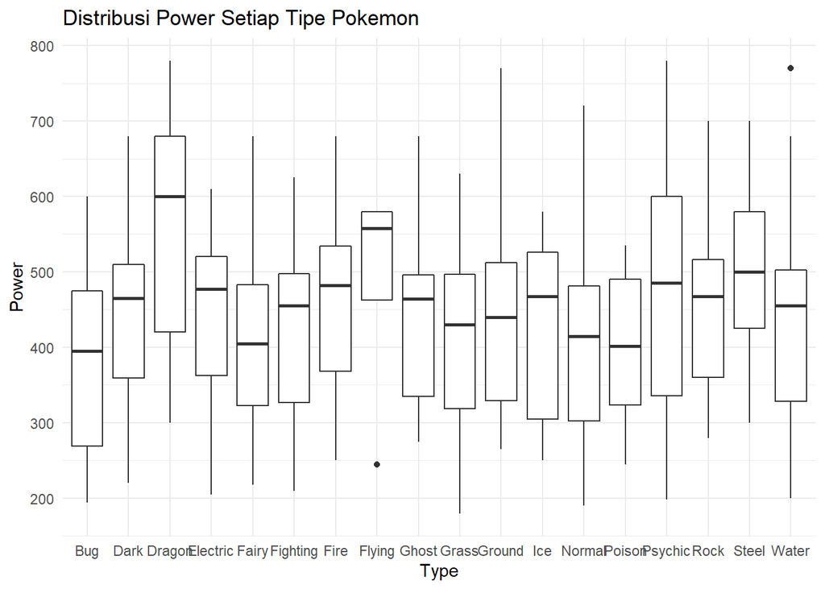

```r
DisType = ggplot(pokemon) +
  geom_boxplot(mapping = aes(x=Type.1, y=Power))+
  scale_y_continuous(breaks = seq(0,800,100))+
  ggtitle('Distribusi Power Setiap Tipe Pokemon')+
  xlab('Type')+
  theme_minimal()
```

Interpretasi :

— Distribusi pokemon bertipe Bug cenderung rendah dibandingkan pokemon Tipe lainnya. Median Power dari Pokemon Tipe Bug adalah **395**, dengan IQR Power sekitar **205**, yang berarti sekitar 50% Pokemon Tipe Bug memiliki power antara **270 - 475**  
Etc..

> COVARIATION: Categorical vs Continous  
> **Bagaimana distribusi dari Power pada pokemon Legendary?**

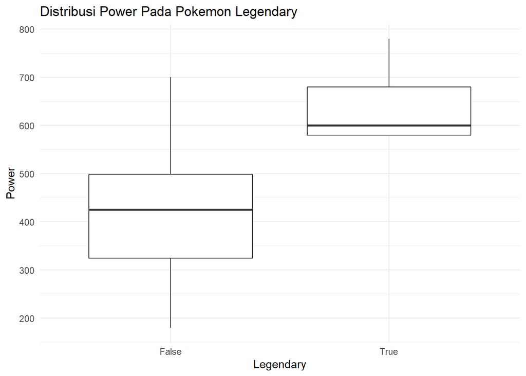

```r
DisLegend = ggplot(pokemon) +
  geom_boxplot(mapping = aes(x=Legendary, y=Power))+
  scale_y_continuous(breaks = seq(0,800,100))+
  ggtitle('Distribusi Power Pada Pokemon Legendary')+
  xlab('Legendary')+
  theme_minimal()
```

Interpretasi :

— Distribusi pokemon legendary cenderung lebih tinggi dibandingkan pokemon non legendary. Median Power dari Legendary Pokemon adalah **600**, dengan IQR Power sekitar **105**, yang berarti sekitar 50% Legendary pokemon memiliki power antara **575 - 685**  
Etc..